# Class 1: Introduction to Python and Jupyter

Let's all open the html file "01_introduction.html", we'll open the corresponding `.ipynb file` (notebook) later.

In this lesson, we will introduce the Python programming language and we will make sure that the Python distribution is working properly.

Prior to starting this class, you should have completed **Class 0: Configuring your computer**.

## Contents

- Class 1: Introduction to Python and Jupyter
  - Introduction to Programming Language
  - Introduction to Python
  - The Python Kernel and interpreter
  - JupyterLab
  - Console
  - Terminal
  - Python File
  - Notebooks (With JupyterLab)
  - Opening a .ipynb file used for Class
  - To .py or to .ipynb?
  - Computing Environment

## Introduction to Programming Language

- A programming language is a structured subset of natural language (words) and special characters (e.g. `,` or `{`) that allow humans to describe operations they would like their computer to perform on their behalf.
- The programming language translates these words and symbols into instructions the computer can execute.

## Introduction to Python

- [Python](https://www.python.org) is a general-purpose programming language conceived in 1989 by Dutch programmer [Guido van Rossum](https://en.wikipedia.org/wiki/Guido_van_Rossum).
- Python is free and open source, with development coordinated through the [Python Software Foundation](https://www.python.org/psf/).

### Common Use

Python

- is very beginner-friendly
- can be used for data analysis, but it can also used for websites, database management, web scraping, financial modeling, data visualization, etc. In particular, it is the world’s best language for [gluing](https://en.wikipedia.org/wiki/Glue_code) those different pieces together.
- is used extensively by Internet services and high tech companies (e.g. [Google](https://www.google.com/))
- is also used to [replace Excel](https://news.efinancialcareers.com/us-en/3002556/python-replaced-excel-banking) in the fields of finance and banking.

### Comparison to Other Languages

Other languages can be more perfomant for other types of tasks. For example:

- R has an impressive ecosystem of statistical packages, and is defensible as a choice for pure data science. It could be a useful second language to learn for projects that are entirely statistical.
- Matlab has much more natural notation for writing linear algebra heavy code. However, it is: (a) expensive; (b) poor at dealing with data analysis; (c) grossly inferior to Python as a language; and (d) being left behind as Python and Julia ecosystems expand to more packages.
- Julia is in part a far better version of Matlab, which can be as fast as Fortran or C. However, it has a young and immature environment and is currently more appropriate for academics and scientific computing specialists.

For runtime performance, Python, R, and Matlab can be slow for certain types of tasks. Most of the data analytics packages in Python (and R) rely on high-performance code written in other languages in the background (i.e. C++). In addition, there are Python/R packages which allow you to write and read your own C program.

### Popularity

This graph by QuantEcon (produced using Stack Overflow Trends) shows one measure of the relative popularity of Python:

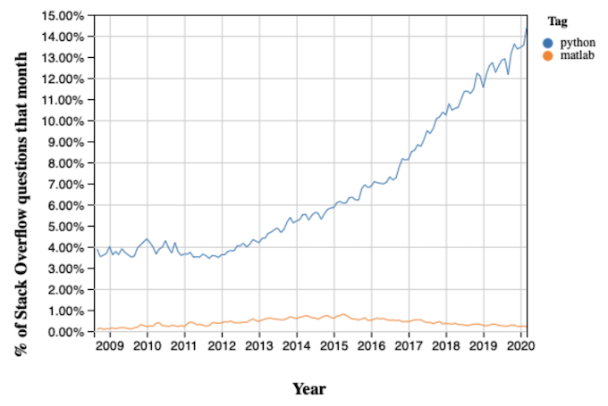

The graph shows that

1. Python is widely used with respect to Matlab
2. The adoption of Python has accelerated significantly since 2012, possibly because of uptake in the scientific domain and thanks to the release of data-abnalysis libraries like [pandas](http://pandas.pydata.org/)

Overall, it’s clear that

- Python is [one of the most popular programming languages worldwide](https://spectrum.ieee.org/computing/software/the-top-programming-languages-2019).
- Python is a major tool for scientific computing, accounting for a rapidly rising share of scientific work around the globe.

### Features

1. Python is a [high-level language](https://en.wikipedia.org/wiki/High-level_programming_language) suitable for rapid development.
2. It has a relatively small core language supported by many libraries.
3. Python is open source and is thus managed on publicly accessible sites (e.g. GitHub) by a large community.
4. Other features of Python:
   - multiple programming styles are supported (procedural, object-oriented, functional, etc.)
   - it is interpreted rather than compiled (see the section The Python kernel and interpreter).

### Syntax and Design

1. Elegant syntax: elegant code might sound superfluous but in fact it’s highly beneficial because it makes the syntax easy to read and easy to remember.
2. Elegant design: features like iterators, generators, decorators and list comprehensions make Python highly expressive, allowing you to get more done with less code.

[Namespaces](https://en.wikipedia.org/wiki/Namespace) improve productivity by cutting down on bugs and syntax errors.

## The Python kernel and interpreter

Let's now have a look of what actually happens behind the scenes when you use Python. This is useful because it allows you to get familiar with terms like kernel and interpreter, which will come up ofter in the applications we will use to run our Python code.

A kernel) is a computer program that facilitates interactions between software components (applications) and hardware (CPU, RAM, other devices). The Python kernel executes your python code. In a simplified way, this means that when you "run" one line of your Python code, the python kernel

1. Takes this line of source code
2. Translates into a set of instructions that your machine can understand (machine code)
3. Gives this set of instructions to RAM and CPU to perform the computation and produce the results.
4. Takes the results and give them back to your console / notebook

The Python interpreter is a program within the Python kernel (also called [interpreter part of the kernel](https://docs.jupyter.org/en/latest/projects/kernels.html)) that trasnlates your code into machine code (step 2). This process (or at least steps 1-3) can be represented as below ([source](https://www.pythontutorial.net/python-concurrency/differences-between-processes-and-threads/)):

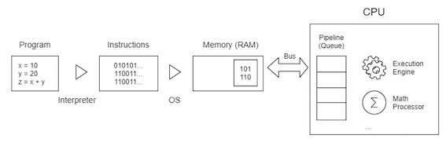

This is why we say that Python is an interpreted language, i.e. each line of code you write is translated, or interpreted, by the Python interpreter into a set of instructions that your machine can understand. This stands in contrast to compiled languages. For these languages (the dominant ones being Fortran, C, and C++), your entire code is translated into machine language before you ever run it. When you execute your program, it is already in machine language.

While the interpreter is usually part of the kernel, you can think of them as the same thing. If you use JupyterLab / Jupyter Notebook, you'll come across the term "kernel". If you use an Integrated Development Environment (IDE) like PyCharm, you'll come across the term "interpreter" (for the definition of IDE check below the section JupyterLab).

So, whenever you want your Python code to run, you give it to the Python interpreter (or kernel). There are many ways to launch the Python interpreter. One way is to type

```
python
```

in the command line of a terminal. This launches the vanilla Python interpreter. We will never really use this in the class. Rather, we will have a greatly enhanced Python experience, either using IPython, a feature-rich, enhanced interactive Python available through JupyterLab's console, or using a notebook, also launchable in JupyterLab.

## JupyterLab

Now that we understand how Python works, let's get you familiar with the most used applications in Anaconda, namely JupyterLab and the Jupter Notebook App. We'll write one line of simple code and we'll run it in JupyterLab through different interfaces and files (console, terminal, python file, notebook), and then in the Jupter Notebook App in a notebook. Note that the source file of the HTML we are reading right now is a notebook file (.ipynb).

**JupyterLab** is a web-based Integrated Development Environment (IDE). An IDE is a software application that provides comprehensive facilities to computer programmers for software development. An IDE normally consists of at least a source code editor, build automation tools and a debugger ([Wikipedia](https://en.wikipedia.org/wiki/Integrated_development_environment)). Often, JupyterLab is used not only for developing software but also for learning how to code, and this is why it is sometimes referred to as Integrated Development and Learning Environment (IDLE). For R users, this is basically a web version of R Studio. JupyterLab is nice as it is a simple IDLE that allows to run Python code through console, terminal, Python file and notebook all in one place, inside the Anaconda Navigator.

To launch **JupyterLab**, open the Anaconda Navigator and click the "launch" icon for JupyterLab. When you do that, a new browser window or tab will open with JupyterLab running. It should look like this:

[figure not shown]

Important things:

- You have a big "+" sign in the upper left corner, which allows you to launch a console, a terminal, a text editor (which you use to write a `.py` file) or a notebook (which you use to write a `.ipynb` file).
- Under the "+" sign, you have the "File Browser" section, with the files in the directory you are currently in (let's select the github folder for the class on your local).
- You then have another section called "Running Terminals and Kernels", in which you can see the list of terminals and kernels running (it will be useful to shut down kernels when we are done).

## Console

Let's start with a Console. The console is the easiest way to launch the Python interpreter/kernel and run your python code. Click the icon "Python 3 (ipykernel)" and you should get a window that looks like this:

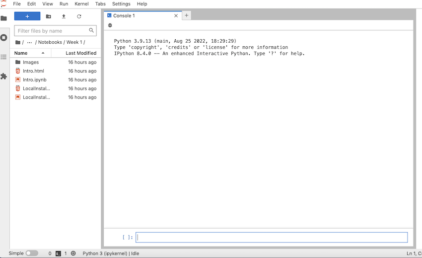

The console window tells you which version of python you are using, the copyrights and the version of IPython. As mentioned before, IPython is a feature-rich, enhanced interactive Python available through JupyterLab's console, which is a nicer way for humans to interact with the Python interpreter than the one offered by the terminal (which we'll see in a moment). Basically, this means that, instead of looking at your terminal and runnning stuff there through Python, you can run stuff through IPython and instead look at this beautiful console in JupyterLab, or at the beautiful notebooks we'll see later. So, in simple words, IPython makes your coding experience nicer.

The console window works with input and output. At the bottom there is the **command line**. You can enter Python code after this sign `[ ]:`, which is called prompt. You can think of this code you insert as the input. The you can press `shift+enter` and the code will be executed. So the kernel/interpreter does its thing (translating into machine language, giving to RAM and CPU for computation, and translating the result back to us), and finally the console will give us back the result of your executed code, which you can think of as the output.

Let's try our first code / program line. Traditionally, the first program anyone writes when learning a new language is called "`Hello, world.`" In this program, the words "`Hello, world.`" are printed on the screen. The original `Hello, world.` was likely written by Brian Kernighan, one of the inventors of Unix, and the author of the classic and authoritative [book](http://www.amazon.com/The-Programming-Language-Brian-Kernighan/dp/0131103628) on the C programming language. In his original, the printed text was "`hello, world`" (no period or capital `H`), but people use lots of variants.

To print `Hello, world.`, enter the code below in the command line of your console. To execute the code, hit `shift+enter`.

```python
print("Hello, world")
```

```
Hello, world
```

BOOOOM! We just printed `Hello, world.` to the screen. To do this, we used Python's built-in `print()` function. The `print()` function takes as **argument** a **string**. It then prints that string to the screen. We will learn more about function syntax later, but we can already see the rough syntax with the `print()` function.

Let's now close the console and shut down the ipykernel we have used from the "Running Terminals and Kernels" section in the left menu of the JupyterLab window, by selecting "Shut Down All", like this:

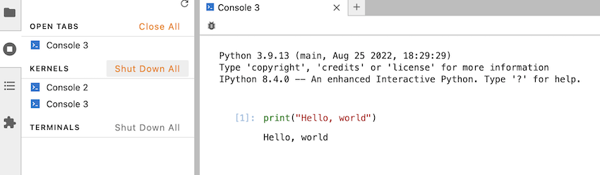

## Terminal

Let's now do the same thing from a terminal. We can either use the terminal / powershell in our computers, or use the terminal in the JupyterLab. Let's use the terminal in JupyterLab. Again, open the launcher by clicking the "+" button in the top left corner, and click the "Terminal" icon under "Other". A terminal window should open like this:

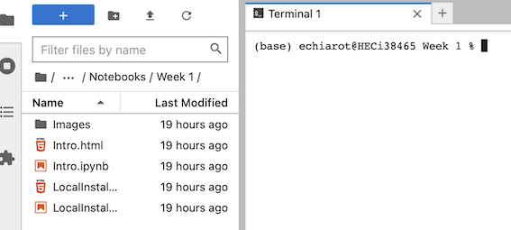

Lets now type `python3` to open the python interpreter (this is the actual python, not ipython). Then let's type `print("Hello, world")`, so the interpreter executes the function print and gives us back the output. Finally, let's exit the python interpeter by typing `exit()`. Your terminal should look something like this:

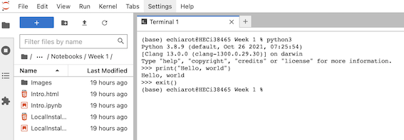

You can now close the terminal window and shut down the terminal from the usual section "Running Terminals and Kernels".

## Python File (.py)

Great! Let's now do the same thing just using a python file. In a nutshell, instead of directly inserting the code in the command line of a console / terminal, we'll write the code in a special text file for python code, namely a `.py` file, and then we'll use a console to open the kernel / interpreter and execute that code (note that you could also run this `.py` file from the terminal).

Working with `.py` files will likely be what you do for the majority of your projects, unless you are either working on teaching and divulgation, for which you can use notebooks (we'll see them next) or collaborating with someone else, for which you can use [Google Collabs](https://colab.research.google.com) or [DeepNote](https://deepnote.com) (if you are not using GitHub).

So, let's create this `.py` file. We'll create it from JupyterLab, but this will be a file that will be saved in your local folders (it's like creating a script file in R or a do.file in Stata). The first thing to do is therefore go in the directory (folder) in your computer where you would like to work. For this exercise, we'll go in the GitHub folder we have created in Class 0, named `class_datascience`, which is the local repository of the forked repository of the upstream repository (remember?). Use the usual tab "File Browser" on the left to find this folder in your computer, which should be located within a `GitHub` folder (that for Mac users should be in `Documents`). In the File Browser of JupyterLab, it should look like this:

[figure not shown]

Then, let's open `Notebooks` -> `Week 1`. At this point, create a new folder by right clicking in the Week 1 folder (place your cursor in the space in the folder where there are no files) and select `New Folder`. Name this new folder `My Files`, as it's shown here:

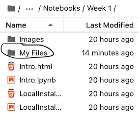

Now double click `My Files` and you are in the right place. Note that you can do the same for any other folder in your computer, depending on where you prefer to work (does not have to be GitHub). Also note that you do not need to always create a folder `My Files`, you can basically organize your folder as you like. Here we did it because you are working in a cloned folder of a forked folder, and in this case it's always good practice to differentiate your files from the ones you have cloned, so when you update this local folder with the updates in the upstream folder, you are always sure that your files are not overwritten. Don't worry if you do not understand this right now, it will become clearer as you use GitHub.

Great! Now we are finally ready to create our first `.py` file. From the JupyterLab launcher, click "Python File" in "Other". As soon as you click it, JupyterLab will (i) open the Editor to edit this file (panel on the right half of your screen), (ii) create a `.py` file called `untitled.py`, and (iii) save it in your current directory, which is `My Files`. Let's rename this file by right clicking on it in the usual left panel and call it `firstfile_YOURINITIALS.py`, as shown here (my initials are EC):

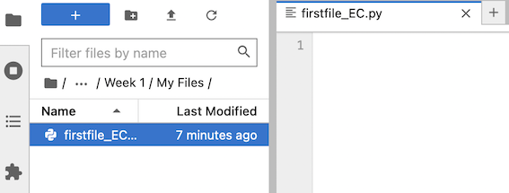

OK. Now, as mentioned, this is just a text type of file - ok `.py` not `.text` but basically same thing. If we write any code in it using the Editor, it'll be just text. We need a way to run this thing (launch the kernel etc). Let's do it through a dedicated console. Click `File` and then `Create Console for Editor`. Select the usual Python 3 (ipykernel), which, again, is the interpreter / kernel we launch as we open the console, remeber? And remember that in the terminal, we had to manually launch this interpreter / kernel by typing `python3`? Veeeeery good.

Your screen should look like this:

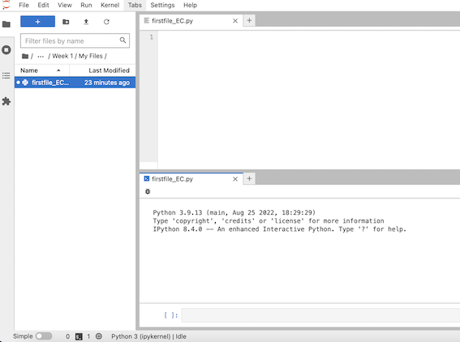

Believe it or not we are ready to go. We have created the `.py` file, we've got the editor open to edit it, we've got a kernel open to run it, and we've got a console open to show the output of the code we have written in the editor (or insert any extra code we want). So type the following in your Editor (right upper panel)

```python
# Usual Hello World
print("Hello, World")

# The first few lines from The Zen of Python by Tim Peters
print('Beautiful is better than ugly.')
print('Explicit is better than implicit.')
print('Simple is better than complex.')
print('Complex is better than complicated.')
```

`#` means that the kernel will ignore what comes after it.

As a first thing, select with your cursor only `print("Hello, world")` and press `shift+enter`. Your ipykernel will execute **only** this line of code and give you back the result in the console, like this:

[figure not shown]

Niiiice! Let's now select the code from lines 4 to 8 and run that chunk with `shift+enter`. If you want to run it all, you can just select it all and press `shift+enter` (do that).

Now, let's save the `.py` file by clicking `File`->`Save Python File`, or with shortcuts `ctrl+s` on Windows and `cmd+s` on Mac. That's it, you have created and saved your first Python file with some python code in it.

## Notebooks (with JupyterLab)

OK we have run some code with console, terminal and editor + console (from a .py file). Another way to write and run python code is the Jupyter Notebook, which is a `.ipynb` document (which stands for **ipy**thon **n**ote**b**ook).

As reported by the [Jupyter Notebook Guide](https://jupyter-notebook-beginner-guide.readthedocs.io/en/latest/what_is_jupyter.html), notebooks are documents produced by the Jupyter Notebook App, an application in the Anaconda Navigator that allows editing and running notebook documents via a web browser. Importantly, notebooks allow to combine computer code (e.g. python) and rich text elements (paragraph, equations, figures, links, etc…). Notebook documents are both human-readable documents containing the analysis description and the results (figures, tables, etc..) as well as executable documents which can be run to perform data analysis.

```python
# Say hello to the world.
print('hello, world.')
```

```
hello, world.
```

OK, now before doing anything else, let's go over some basic concepts of how cells work in a Notebook.

### Cells

A Jupyter notebook consists of **cells**.

There are two modes to work with cells, namely **command mode** and **edit mode**.

- The first one is the command mode. When you are in command mode, the full cell is selected, and the cell will be grey in JupyterLab (or green in Jupyter Notebook App). To be in command mode, select the cell and press `esc`. This mode will allow you to navigate across cell and run them by pressing `ctrl+enter` for Windows and `cmd+enter` for Mac.
- The second one is the edit mode. When you are in edit mode, the cursor will be inside the cell, and you will be able to edit it. In edit mode, the cell will become white in JupyterLab (or blue in Jupyter Notebook App). To go from command mode to edit mode, select the cell in command mode and press `enter`. When you are done editing the cell, you can run it (and go back to command mode) by pressing `ctrl+enter` for Windows and `cmd+enter` for Mac.

The two main types of cells you will use are **code cells** and **markdown cells**.

- A code cell contains actual code that you want to run. Basically, a code cell is like the command line in the console. You can specify a cell as a code cell using the pulldown menu in the toolbar of your Jupyter notebook. Otherwise, you can hit `Esc` and then `y` (denoted `Esc - y`") while a cell is selected to specify that it is a code cell. Note that you will have to hit enter after doing this to start editing it. Note that code cells are executed in the order you shift-enter them. That is to say, the ordering of the cells for which you hit `Shift + Enter` is the order in which the code is executed. If you did not explicitly execute a cell early in the document, its results are not known to the Python interpreter. **This is a very important point and is often a source of confusion and frustration for students.**
- Markdown cells contain text. The text is written in **markdown**, a lightweight markup language. You can read about its syntax [here](http://daringfireball.net/projects/markdown/syntax). Note that you can also insert HTML into markdown cells, and this will be rendered properly. As you are typing the contents of these cells, the results appear as text. Hitting `Shift + Enter` renders the text in the formatting you specify. You can specify a cell as being a markdown cell in the Jupyter toolbar, or by hitting `Esc - m` in the cell. Again, you have to hit enter after using the quick keys to bring the cell into edit mode.

The keyboard shortcuts to do these operations with cells are summarized here. Importantly, pressing `Esc` brings you into command mode in which you are not editing the contents of a single cell, but are doing things like adding cells. The `-` sign means the keys must be pressed in succession.

| Quick keys | mode | action |
| --- | --- | --- |
| `Esc - m` | command | switch cell to Markdown cell |
| `Esc - y` | command | switch cell to code cell |
| `Esc - a` | command | insert cell above |
| `Esc - b` | command | insert cell below |
| `Esc - d - d` | command | delete cell |

Try all of these in the Notebook that you have created. There are many others, and you can access them via the "open command palette" icon (keyboard looking icon) in the Jupyter Notebook App.

### Editing and Saving Notebooks

Great, let's now add some more stuff to the notebook. Add a new cell (`cmd+b`), and copy the following code.

```python
# Would show 9 if this were the last line, but it is not, so shows nothing
4 + 5

# I hope we see 11.
5 + 6
```

```
11
```

You can see that when you evaluate a Python expression that returns a value, that value is displayed as output of the code cell. This only happens for the last line of the code cell.

Now, add 2 new cells that look like these (copy and paste the code from these 2 cells):

```python
# Variable assignment, so no visible output.
a = 5 + 6
```

```python
# However, now if we ask for a, its value will be displayed
a
```

```
11
```

You can see that if the last line does not return a value, such as if we assigned value to a variable, there is no visible output from the code cell. To actually return that value, we need to run the object `a`.

Great! Now that we have edited our notebook, press `ctrl+s` for Windows and `cmd+s` for Mac to save it. You can also save this file in other formats, for example HTML as we did to create the HTML files for this class. To do that, you can go to `File` -> `Save and Export Notebook As ...` and select HTML.

## Opening a .ipynb file used for Class

Using notebooks (instead of HTML) allows you to:

- Run the code as we go through it in class, and check that everything works
- Add your own notes and modifications in class, so you can go back to them later

For the GitHub aficionados, you can commit and push these new files to GitHub (in fact, all the new files we have created in this class). This means that you are saving the changes you made on local (through JupyterLab) in the cloud of GitHub. You can do this with GitHub Desktop. Open GitHub Desktop, select the repository `class_datascience` (which, remember, is the clone of a fork of the original repository of the class), and commit your changes to the main branch of the fork, as shown here:

[figure not shown]

As changes are now committed, you need to push them to save them in the forked repository in the cloud. Click "Push Origin" in the desktop app as shown here and you are done:

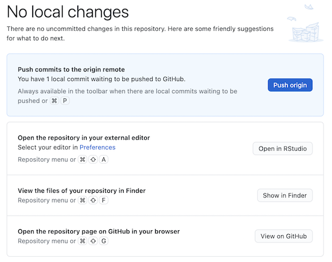

## Notebooks with Jupyter Notebook App

We are almost done. As a last thing, let's see how we can open a notebook with the basic Jupyter Notebook App, which is a server-client application that allows editing and running notebook documents via a web browser. The Jupyter Notebook App can be executed on a local desktop requiring no internet access or can be installed on a remote server and accessed through the internet.

When we are working on notebooks, there are some advantages to using the App rather than JupyterLab. For example, the editor is more basic and full window, which is nicer and larger than the interface offered by JupyterLab. Indeed, lots of people working on notebooks use directly the App.

To launch **Jupyter Notebook App**, click the "launch" icon for Notebook in the Anaconda Navigator. When you do that, a new browser window or tab will open with the home page of Jupyter Notebook, with 3 mains sections.

- The section "Files" shows all the folders in your computer. You can navigate these folders to find the notebooks you have saved locally and open them.
- The section "Running" shows the list of terminals and notebooks running. For the notebooks, you'll see running the ones you have currently opened. You should also see which Kernel the notebook is using, i.e. `Python 3 (ipykernel)` and the option to shut down this kernel. When you want to close a notebook, you can close the respective browser window, and then go back to the "Running" section in the main window of the App, and shut down the kernels for the closed notebooks (usually ipykernel).
- The section "Clusters" shows you which clusters are active. We'll see if we have time to cover clusters in this class.

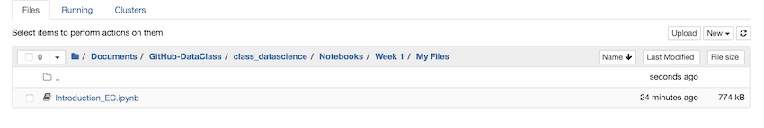

To create a new `.ipynb` in the same directory, you can simply click the button "New" that you see in the upper right corner of this screenshot.

Overall, this App allows you to work with Notebooks in a simple way. It's good to know what it is because when we'll show you notebooks it'll be mostly from this App. It is up to you if you want to use this App or JupyterLab.

AMAZING!! You are now finally ready to do some coding (in the next class)!

## To `.py` or to `.ipynb`?

When writing code you will reuse, you should develop fully tested modules using Python files (`.py`). So, a Jupyter notebook is not good for an application where you are building reusable code or scripts. However, Jupyter notebooks (`.ipynb`) are **very** useful in the following applications:

1. *Exploring data/analysis.* Jupyter notebooks are great for trying things out with code, or exploring a data set. This is an important part of the research process. The layout of Jupyter notebooks is great for organizing thoughts as you synthesize them.
2. *Developing image processing pipelines.* This is really just a special case of (1), but it worth mentioning separately because Jupyter notebooks are especially useful when figuring out what steps are best for extracting useful data from images. Using the Jupyter notebook, you can write down what you hope to accomplish in each step of processing and then graphically show the results as images as you go through the analysis. We will do this later in the class.
3. *Sharing your thinking in your analysis.* Because you can combine nicely formatted text and executable code, Jupyter notebooks are great for sharing how you go about doing your calculations with collaborators and with readers of your publications.
4. *Teaching.* Yes, all of the content in this class was developed using Jupyter notebooks!

## Computing environment

The python interpreter/kernel is deployed and executed in the base environment of Anaconda. An environment is a computer system or set of systems in which a computer program or software component is deployed and executed. In a nutshell, the python kernel is executed in the Anaconda base environment, where it reads all the packages that are saved there. Later on in this class, in case of need, we will create a new custom environment, where we'll save all the packages we need, with the versions we want, and we will set a specific kernel / interpreter, of the python version we want. Indeed, each environment should have its own kernel. You can find [here](https://www.youtube.com/watch?v=6kXLUvsnhuI) a quick video explanation on how to create Anaconda virtual environments and associated new kernels for Jupyter notebooks.

The watermark package is quite useful for this. The watermark package is an IPython magic extension. These extensions allow convenient functionality within IPython or Jupyter notebooks. In general, to use magic functions, you precede them with a `%` sign or a `%%` in a cell. We use the built-in `%load_ext` magic function to load watermark, and then we use `%watermark` to invoke it.

We use the `-v` flag to ask watermark to give us the Python and IPython verison numbers and the `-p` flag to give us version numbers on specified packages we’ve used.

```python
%load_ext watermark
%watermark -v -p jupyterlab
```

```
Python implementation: CPython
Python version       : 3.9.13
IPython version      : 8.4.0

jupyterlab: 3.4.4
```